# HW 2

Marion Geary

```r
library(fivethirtyeight)
library(tidyverse)
library(knitr)
library(ggthemes)
data("bechdel")
```

### Exercise 1

```r
bechdel90.13 <- filter(bechdel, between(year, 1990, 2013))
```

### Exercise 2

```r
budget_summary_binary <- bechdel90.13 %>% group_by(binary) %>% select(budget_2013, domgross_2013, intgross_2013) %>% summarize(med_budget = median(budget_2013, na.rm = T), med_domgross = median(domgross_2013, na.rm = T), med_intgross = median(intgross_2013, na.rm = T))
budget_summary_binary
```

| binary | med_budget | med_domgross | med_intgross |
| --- | --- | --- | --- |
| FAIL | 48385984 | 57318606 | 104475669 |
| PASS | 31070724 | 45330446 | 80124349 |

Though these analysis, we see that movies that fail the Bechdel test have higher median budgets and higher median international and domestic gross.

### Exercise 3

```r
budget_summary_clean <- bechdel90.13 %>% group_by(clean_test) %>% select(budget_2013, domgross_2013, intgross_2013) %>% summarize(med_budget = median(budget_2013, na.rm = T), med_domgross = median(domgross_2013, na.rm = T), med_intgross = median(intgross_2013, na.rm = T))
budget_summary_clean
```

| clean_test | med_budget | med_domgross | med_intgross |
| --- | --- | --- | --- |
| nowomen | 43373066 | 44891296 | 89509349 |
| notalk | 56570084 | 63890455 | 123102194 |
| men | 39737690 | 56392786 | 99578022 |
| dubious | 35790994 | 49173429 | 89883201 |
| ok | 31070724 | 45330446 | 80124349 |

Dubious means that some contributors to the data were skeptical about whether the film passed the test.

Through grouping by the specific results of the Bechdel test, we find that movies that have women that never talk to each other have the highest median budgets, domestic gross, and international gross. These movie’s numbers are significantly higher than those in the categories. Movies that pass the test still have the lowest budgets and lowest international gross. They have the second lowest domestic gross by a small margin.

## Exercise 4

```r
bechdel90.13 <- bechdel90.13 %>% mutate(roi = round(domgross_2013 / budget_2013, digits = 2), .after = year) %>% arrange(roi)
```

## Exercise 5

```r
roi_over_30 <- bechdel90.13 %>% filter(roi > 30) %>% select(year, roi, title, clean_test, binary, budget_2013, domgross_2013)

kable(roi_over_30)
```

| year | roi | title | clean_test | binary | budget_2013 | domgross_2013 |
| --- | --- | --- | --- | --- | --- | --- |
| 2010 | 36.01 | Insidious | ok | PASS | 1602348 | 57694294 |
| 2004 | 45.99 | Saw | men | FAIL | 1479831 | 68053804 |
| 1998 | 47.37 | Pi | men | FAIL | 97181 | 4603452 |
| 1997 | 48.03 | Chasing Amy | ok | PASS | 362810 | 17424311 |
| 2002 | 48.29 | My Big Fat Greek Wedding | ok | PASS | 6475896 | 312705749 |
| 2012 | 53.26 | The Devil Inside | ok | PASS | 1014639 | 54041622 |
| 1991 | 53.37 | Slacker | ok | PASS | 39349 | 2100070 |
| 2004 | 60.68 | Primer | notalk | FAIL | 8632 | 523811 |
| 2006 | 62.97 | Once | men | FAIL | 173369 | 10917487 |
| 2008 | 66.91 | Fireproof | men | FAIL | 541128 | 36208310 |
| 2004 | 111.35 | Napoleon Dynamite | notalk | FAIL | 493277 | 54927590 |
| 1994 | 113.83 | Clerks. | notalk | FAIL | 42435 | 4830398 |
| 1997 | 115.35 | In the Company of Men | notalk | FAIL | 36281 | 4184879 |
| 1999 | 234.23 | The Blair Witch Project | ok | PASS | 839077 | 196538593 |
| 2007 | 239.82 | Paranormal Activity | dubious | FAIL | 505595 | 121251476 |
| 1992 | 291.57 | El Mariachi | nowomen | FAIL | 11622 | 3388636 |

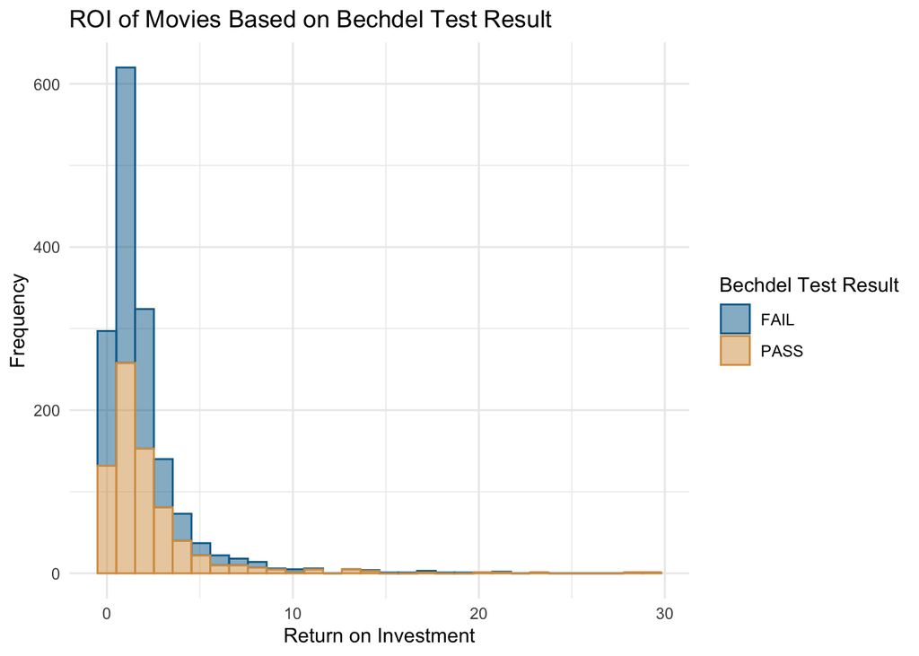

```r
roi_under_30 <- bechdel90.13 %>% filter(roi < 30) %>% select(year, roi, title, clean_test, binary, budget_2013, domgross_2013)

library(wesanderson)
my_colors <- wesanderson::wes_palette("Darjeeling2")[2:4]

ggplot(roi_under_30, aes(x = roi, fill = binary, color = binary)) + geom_histogram(alpha = 0.5)  + theme_minimal() + scale_color_manual(values = my_colors) +
  scale_fill_manual(values = my_colors) + labs(x = "Return on Investment", y = "Frequency", title = "ROI of Movies Based on Bechdel Test Result", color = "Bechdel Test Result", fill = "Bechdel Test Result") + theme_minimal()
```

Through this analysis, I noticed that a higher proportion of movies with lower ROIs fail the Bechdel test. Fewer of the movies with high ROIs pass the Bechdel test. Of the high ROI (`roi > 30`) movies that do not pass the Bechdel test, only one has no women. Overall, most movies have low ROIs, but the data is very right skewed.